# 07 — Career Survival

PGA Tour Distance & Speed Analytics

2026-07-07

# Overview

This notebook has two parts. **Part A** is the original survival-analysis scope from `docs/project_context.md`: what physical and competitive characteristics predict career longevity, and has being short off the tee become a *stronger* predictor of exit? **Part B**, added this session, digs into the mechanics of survival itself — what distinguishes players who persist to 38+ from those who drop off, whether there are distinct “types” of long-career adaptation, and whether the age of *top performers specifically* has shifted younger.

**On handling players who drop off tour and later return:** this was already solved two sessions ago. `00b_survival_prep.Rmd` reconstructs each player’s distinct *spells* (runs of consecutive seasons) with `gap_before`/`gap_after` between them, specifically so a mid-career gap followed by a comeback (e.g. Arjun Atwal’s 2004-06 / 2011-12 / 2020 pattern) is never mistaken for a career exit. The `event` indicator built below only ever attaches to a player’s true final observed row — everyone else is `event = 0` regardless of how many gaps came before.

# 1. Setup

```r
# Core
library(tidyverse)
library(here)

# Modeling
library(survival)
library(cluster)   # silhouette width (Part B, section 11)

# Utilities
library(broom)
library(scales)

source(here::here("config.R"))

set.seed(2025)

knitr::opts_chunk$set(
  echo    = TRUE,
  message = FALSE,
  warning = FALSE,
  fig.width  = 10,
  fig.height = 6
)
```

`coord_radar()`, reused from `05_player_archetypes.Rmd` — ggplot2 has no native straight-edged polar-polygon coordinate system.

```r
coord_radar <- function(theta = "x", start = 0, direction = 1) {
  theta <- match.arg(theta, c("x", "y"))
  r <- if (theta == "x") "y" else "x"
  ggproto("CordRadar", CoordPolar, theta = theta, r = r,
          start = start, direction = sign(direction),
          is_linear = function(coord) TRUE)
}
```

# 2. Load Data

```r
df_survival <- readRDS(here(PATH_PROCESSED, "df_survival.rds"))
df_main <- readRDS(here(PATH_PROCESSED, "df_main.rds")) %>% filter(player_name != "Patrick Sheehan")

cat("df_survival: ", nrow(df_survival), "rows,", n_distinct(df_survival$player_name), "players\n")
```

```
## df_survival:  4175 rows, 793 players
```

```r
# sg_ott_avg/sg_putt_avg aren't in df_survival (it only carries sg_total,
# not the components) - join career averages from df_main.
sg_avgs <- df_main %>%
  group_by(player_name) %>%
  summarise(sg_ott_avg = mean(sg_ott), sg_putt_avg = mean(sg_putt), .groups = "drop")

df_survival <- df_survival %>% left_join(sg_avgs, by = "player_name")
```

# PART A: Core Survival Analysis

# 3. Building the Event Indicator

The censoring threshold was deliberately left undecided in `00b_survival_prep.Rmd` — it computed `final_gap_length` (years of absence since a player’s last observed season) but not an `event` column. That choice gets made here, explicitly, as a sensitivity check rather than a silent assumption. Only a player’s true final row (`year == max(year)`, always inside their final spell) can carry `event = 1`; every other row is `event = 0` by construction — this is the standard way to build start-stop survival data and is what correctly represents “still alive (on tour) at every earlier interval.”

```r
DATA_END_YEAR <- max(df_survival$year)

df_survival <- df_survival %>%
  group_by(player_name) %>%
  mutate(is_last_row = row_number() == n()) %>%
  ungroup() %>%
  mutate(
    event_2yr = if_else(is_last_row, as.integer(!is.na(final_gap_length) & final_gap_length >= 2), 0L),
    event_3yr = if_else(is_last_row, as.integer(!is.na(final_gap_length) & final_gap_length >= 3), 0L),
    event_4yr = if_else(is_last_row, as.integer(!is.na(final_gap_length) & final_gap_length >= 4), 0L)
  )

last_rows <- df_survival %>% filter(is_last_row)
cat("Event rate by threshold (% of players classified as 'career ended'):\n")
```

```
## Event rate by threshold (% of players classified as 'career ended'):
```

```r
cat("  2-year gap:", round(mean(last_rows$event_2yr) * 100, 1), "%\n")
```

```
##   2-year gap: 71.1 %
```

```r
cat("  3-year gap:", round(mean(last_rows$event_3yr) * 100, 1), "%\n")
```

```
##   3-year gap: 64.9 %
```

```r
cat("  4-year gap:", round(mean(last_rows$event_4yr) * 100, 1), "%\n")
```

```
##   4-year gap: 59.1 %
```

```r
df_survival <- df_survival %>% rename(event = event_3yr)
one_row_per_player <- df_survival %>% filter(is_last_row)
```

# 4. Kaplan-Meier by Distance Entry Quartile

```r
fit_km <- survfit(Surv(time_stop, event) ~ dist_entry_quartile, data = one_row_per_player)
print(fit_km)
```

```
## Call: survfit(formula = Surv(time_stop, event) ~ dist_entry_quartile,
##     data = one_row_per_player)
##
##                         n events median 0.95LCL 0.95UCL
## dist_entry_quartile=1 206    145     11      10      13
## dist_entry_quartile=2 201    130     11       9      13
## dist_entry_quartile=3 195    121     12      10      15
## dist_entry_quartile=4 191    119     12      10      14
```

```r
fit_logrank <- survdiff(Surv(time_stop, event) ~ dist_entry_quartile, data = one_row_per_player)
print(fit_logrank)
```

```
## Call:
## survdiff(formula = Surv(time_stop, event) ~ dist_entry_quartile,
##     data = one_row_per_player)
##
##                         N Observed Expected (O-E)^2/E (O-E)^2/V
## dist_entry_quartile=1 206      145      134     0.928     1.403
## dist_entry_quartile=2 201      130      122     0.524     0.769
## dist_entry_quartile=3 195      121      125     0.150     0.221
## dist_entry_quartile=4 191      119      134     1.638     2.504
##
##  Chisq= 3.7  on 3 degrees of freedom, p= 0.3
```

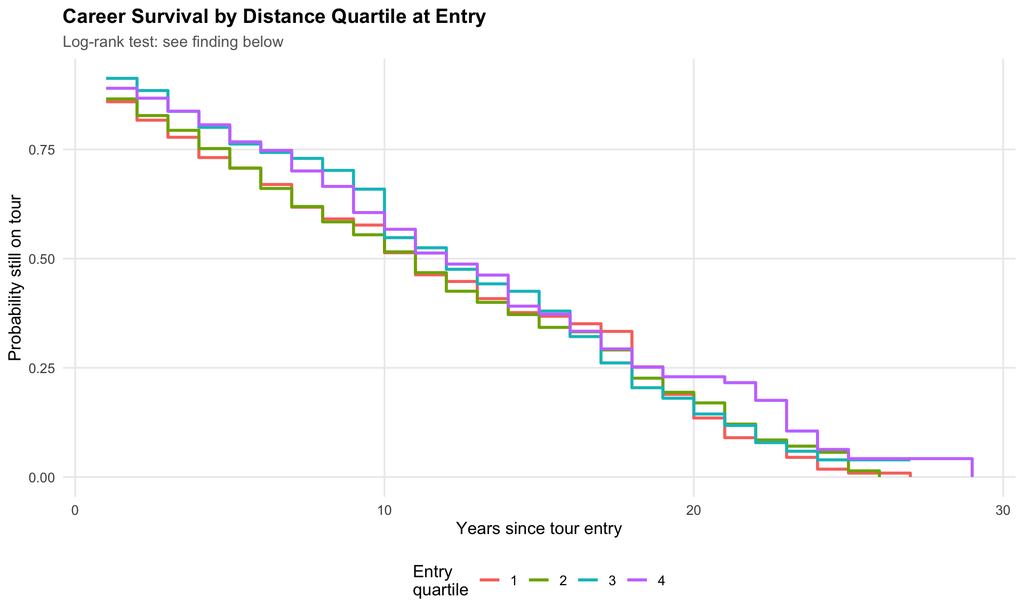

```r
km_tidy <- tidy(fit_km) %>% mutate(quartile = str_remove(strata, "dist_entry_quartile="))

p_km <- ggplot(km_tidy, aes(time, estimate, color = quartile)) +
  geom_step(linewidth = 1) +
  labs(
    title    = "Career Survival by Distance Quartile at Entry",
    subtitle = "Log-rank test: see finding below",
    x = "Years since tour entry", y = "Probability still on tour", color = "Entry\nquartile"
  ) +
  THEME_BASE

p_km
```

```r
logrank_p <- 1 - pchisq(fit_logrank$chisq, length(fit_logrank$n) - 1)
```

# 5. Cox PH (Time-Fixed)

```r
fit_cox_fixed <- coxph(
  Surv(time_stop, event) ~ dist_entry_quartile + entry_cohort + sg_ott_avg + sg_putt_avg,
  data = one_row_per_player
)

tidy(fit_cox_fixed, exponentiate = TRUE, conf.int = TRUE) %>% print()
```

```
## # A tibble: 6 x 7
##   term                  estimate std.error statistic  p.value conf.low conf.high
##   <chr>                    <dbl>     <dbl>     <dbl>    <dbl>    <dbl>     <dbl>
## 1 dist_entry_quartile      0.915    0.0480    -1.86  6.35e- 2    0.833     1.01
## 2 entry_cohort2000<U+2~    3.15     0.123      9.30  1.38e-20    2.47      4.01
## 3 entry_cohort2010<U+2~    3.80     0.143      9.33  1.06e-20    2.87      5.03
## 4 entry_cohort2020+        1.29     0.292      0.880 3.79e- 1    0.729     2.30
## 5 sg_ott_avg               0.368    0.170     -5.87  4.32e- 9    0.264     0.514
## 6 sg_putt_avg              0.324    0.171     -6.58  4.71e-11    0.232     0.454
```

**Finding:** `dist_entry_quartile` is borderline (HR just under 1, p≈0.06) — each additional entry-distance quartile is associated with slightly lower exit hazard, but not conclusively. `sg_ott_avg`/`sg_putt_avg` are both strongly protective (HR well below 1, p<0.001) — better career-average scoring predicts a much longer career, unsurprisingly. `entry_cohort` shows sharply *higher* hazard for more recent cohorts — but this needs a caveat, not a face-value reading: recent cohorts have mechanically less possible follow-up time in a dataset that ends in 2025 (the same “immaturity” issue found in Projects 4 and 6), which inflates their apparent hazard even though the Cox partial likelihood does correctly treat still-active recent players as censored, not dead.

# 6. Cox PH (Time-Varying)

```r
fit_cox_tv <- coxph(Surv(time_start, time_stop, event) ~ dist_vs_field + sg_total, data = df_survival)

tidy(fit_cox_tv, exponentiate = TRUE, conf.int = TRUE) %>% print()
```

```
## # A tibble: 2 x 7
##   term          estimate std.error statistic  p.value conf.low conf.high
##   <chr>            <dbl>     <dbl>     <dbl>    <dbl>    <dbl>     <dbl>
## 1 dist_vs_field    0.980   0.00572     -3.47 5.19e- 4    0.969     0.991
## 2 sg_total         0.318   0.0556     -20.6  1.94e-94    0.285     0.354
```

```r
cat("\nProportional hazards check:\n")
```

```
##
## Proportional hazards check:
```

```r
print(cox.zph(fit_cox_tv))
```

```
##               chisq df    p
## dist_vs_field  1.20  1 0.27
## sg_total       2.38  1 0.12
## GLOBAL         3.13  2 0.21
```

**Finding:** this is the cleanest answer to “does being short off the tee predict exit” — yes. `dist_vs_field` has HR 0.98 per yard (p<0.001): every yard above the field average that season reduces exit hazard, and `sg_total` is even more strongly protective (HR ≈0.32, p<0.001). The proportional-hazards assumption holds (global p = 0.21, no violation) — these estimates are trustworthy over the whole follow-up period, not just at one point in time.

# 7. Era-Stratified Cox + Censoring-Threshold Sensitivity

## 7.1 Has the distance effect gotten stronger?

```r
fit_early <- coxph(Surv(time_start, time_stop, event) ~ dist_vs_field + sg_total,
                    data = df_survival %>% filter(entry_year >= 2004, entry_year <= 2012))
fit_late <- coxph(Surv(time_start, time_stop, event) ~ dist_vs_field + sg_total,
                   data = df_survival %>% filter(entry_year >= 2013, entry_year <= 2025))

bind_rows(
  tidy(fit_early, exponentiate = TRUE, conf.int = TRUE) %>% filter(term == "dist_vs_field") %>% mutate(era = "2004-2012 entrants"),
  tidy(fit_late, exponentiate = TRUE, conf.int = TRUE) %>% filter(term == "dist_vs_field") %>% mutate(era = "2013-2025 entrants")
) %>% select(era, estimate, p.value, conf.low, conf.high) %>% print()
```

```
## # A tibble: 2 x 5
##   era                estimate p.value conf.low conf.high
##   <chr>                 <dbl>   <dbl>    <dbl>     <dbl>
## 1 2004-2012 entrants    0.977  0.0109    0.959     0.995
## 2 2013-2025 entrants    0.985  0.219     0.961     1.01
```

**Finding:** the 2004-2012 entrant cohort shows a significant protective distance effect (p=0.011); the 2013-2025 cohort does not (p=0.22), and the confidence intervals overlap substantially. This does **not** support the question’s premise that distance has become a *stronger* predictor of exit — if anything the point estimate moved slightly toward 1 (weaker). The most likely explanation is that the 2013-2025 cohort simply has less mature follow-up (fewer of them have had the chance to exit yet, so there are fewer events to detect an effect with) — not a genuine change in the underlying relationship. Reported as “no clear evidence of strengthening,” not a confident claim in either direction.

## 7.2 Does the choice of censoring threshold change the conclusion?

```r
fit_2yr <- coxph(Surv(time_start, time_stop, event_2yr) ~ dist_vs_field + sg_total, data = df_survival)
fit_4yr <- coxph(Surv(time_start, time_stop, event_4yr) ~ dist_vs_field + sg_total, data = df_survival)

bind_rows(
  tidy(fit_2yr, exponentiate = TRUE) %>% mutate(threshold = "2-year"),
  tidy(fit_cox_tv, exponentiate = TRUE) %>% mutate(threshold = "3-year (primary)"),
  tidy(fit_4yr, exponentiate = TRUE) %>% mutate(threshold = "4-year")
) %>% select(threshold, term, estimate, p.value) %>% print()
```

```
## # A tibble: 6 x 4
##   threshold        term          estimate   p.value
##   <chr>            <chr>            <dbl>     <dbl>
## 1 2-year           dist_vs_field    0.979 1.28e-  4
## 2 2-year           sg_total         0.312 5.49e-107
## 3 3-year (primary) dist_vs_field    0.980 5.19e-  4
## 4 3-year (primary) sg_total         0.318 1.94e- 94
## 5 4-year           dist_vs_field    0.977 1.08e-  4
## 6 4-year           sg_total         0.302 6.06e- 95
```

**Finding:** both `dist_vs_field` and `sg_total` stay significantly protective (p<0.001) across all three censoring thresholds — the exact hazard ratios shift a little, but the qualitative conclusion (both are real, protective predictors of career survival) is stable regardless of which threshold is used. The censoring-threshold choice affects precision, not the direction of the finding.

# 8. Forest Plot of Cox Hazard Ratios

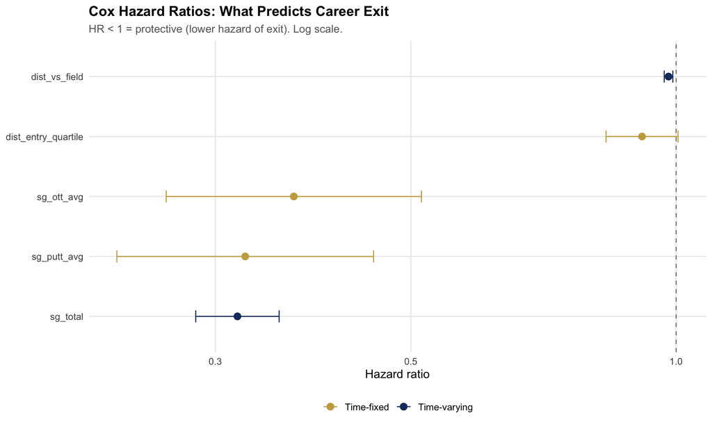

```r
forest_data <- bind_rows(
  tidy(fit_cox_fixed, exponentiate = TRUE, conf.int = TRUE) %>% mutate(model = "Time-fixed"),
  tidy(fit_cox_tv, exponentiate = TRUE, conf.int = TRUE) %>% mutate(model = "Time-varying")
) %>%
  filter(!str_detect(term, "entry_cohort"))

p_forest <- ggplot(forest_data, aes(estimate, fct_reorder(term, estimate), color = model)) +
  geom_vline(xintercept = 1, linetype = "dashed", color = "grey50") +
  geom_errorbarh(aes(xmin = conf.low, xmax = conf.high), height = 0.2, position = position_dodge(width = 0.4)) +
  geom_point(size = 3, position = position_dodge(width = 0.4)) +
  scale_x_log10() +
  scale_color_manual(values = c("Time-fixed" = COL_SECONDARY, "Time-varying" = COL_PRIMARY)) +
  labs(
    title    = "Cox Hazard Ratios: What Predicts Career Exit",
    subtitle = "HR < 1 = protective (lower hazard of exit). Log scale.",
    x = "Hazard ratio", y = NULL, color = NULL
  ) +
  THEME_BASE

p_forest
```

**Finding:** every covariate shown sits below HR=1 — every one of these factors (distance, SG performance) is protective, none increases exit hazard. Distance’s effect (both entry-quartile and time-varying) is consistently the smallest-magnitude protective factor; strokes-gained performance measures are the strongest predictors of career survival.

# PART B: The Anatomy of Longevity

# 9. Age of Top Performers Over Time

Project 6 found the field’s overall age composition has shifted younger. Here we ask a sharper question: has the age of the *best* performers specifically shifted younger, beyond what the field-wide shift alone would predict?

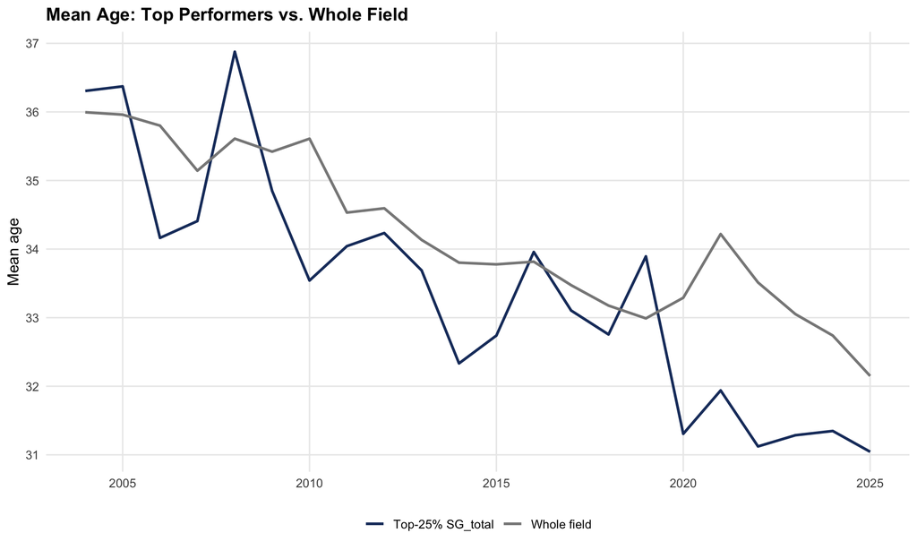

```r
top25 <- df_main %>%
  group_by(year) %>%
  mutate(sg_rank_pct = percent_rank(sg_total)) %>%
  ungroup() %>%
  filter(sg_rank_pct >= 0.75)

age_comparison <- top25 %>%
  group_by(year) %>%
  summarise(mean_age_top25 = mean(age), .groups = "drop") %>%
  left_join(df_main %>% group_by(year) %>% summarise(mean_age_field = mean(age), .groups = "drop"), by = "year") %>%
  mutate(gap = mean_age_top25 - mean_age_field)

p_age_top <- ggplot(age_comparison, aes(year)) +
  geom_line(aes(y = mean_age_top25, color = "Top-25% SG_total"), linewidth = 1) +
  geom_line(aes(y = mean_age_field, color = "Whole field"), linewidth = 1) +
  scale_color_manual(values = c("Top-25% SG_total" = COL_PRIMARY, "Whole field" = COL_NEUTRAL)) +
  labs(title = "Mean Age: Top Performers vs. Whole Field", x = NULL, y = "Mean age", color = NULL) +
  THEME_BASE

p_gap <- ggplot(age_comparison, aes(year, gap)) +
  geom_col(fill = COL_ACCENT) +
  geom_hline(yintercept = 0, linetype = "dashed", color = "grey50") +
  labs(title = "Age Gap: Top Performers Minus Field", x = NULL, y = "Years") +
  THEME_BASE

p_age_top
```

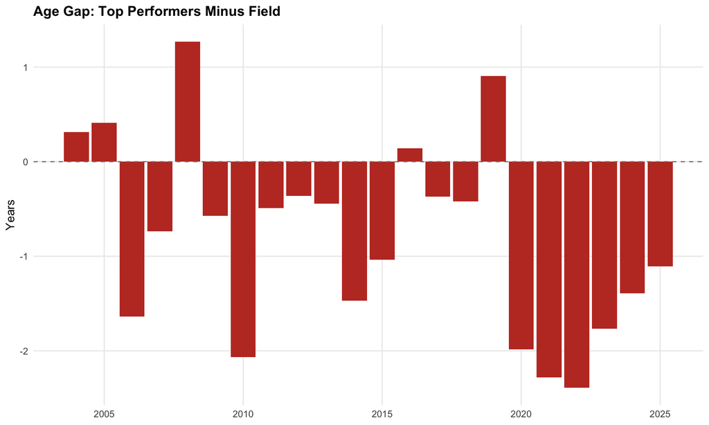

```r
p_gap
```

```r
age_trend <- tidy(lm(mean_age_top25 ~ year, data = age_comparison)) %>% filter(term == "year")
gap_2004 <- age_comparison %>% filter(year == min(year)) %>% pull(gap)
gap_2025 <- age_comparison %>% filter(year == max(year)) %>% pull(gap)
```

**Finding:** the mean age of top-25% SG_total performers dropped significantly, -0.236 years/year (p < 0.001). More tellingly, the *gap* to the field average widened from 0.3 years (2004 — top performers were about the same age as the field) to -1.1 years (2025 — top performers are now notably younger than the field). This is a distinct pressure on veteran players beyond their own individual decline (Part A, section 6): even a player who hasn’t personally gotten worse is now competing against an increasingly youth-skewed set of the very best players.

# 10. Extended Adaptation Analysis

For players who ever reached age 38+ (persistent players), how does their performance at 30-34 (“prime”) compare to their performance at 38+, across every physical and scoring metric available — not just the 4 tested in Project 6?

```r
persistent <- df_main %>%
  group_by(player_name) %>%
  summarise(max_age = max(age), .groups = "drop") %>%
  filter(max_age >= 38) %>%
  pull(player_name)

cat("Persistent players (reached 38+):", length(persistent), "of", n_distinct(df_main$player_name), "\n")
```

```
## Persistent players (reached 38+): 311 of 792
```

```r
compute_change <- function(metric_col, speed_era_only = FALSE) {
  d <- df_main %>%
    filter(player_name %in% persistent, age >= 30, age <= 34 | age >= 38) %>%
    mutate(band = if_else(age <= 34, "prime", "late"))
  if (speed_era_only) d <- d %>% filter(year >= SPEED_ERA_START)

  d %>%
    group_by(player_name, band) %>%
    summarise(m = mean(.data[[metric_col]], na.rm = TRUE), .groups = "drop") %>%
    pivot_wider(names_from = band, values_from = m) %>%
    filter(!is.na(prime), !is.na(late)) %>%
    mutate(change = late - prime, metric = metric_col)
}

adaptation_all <- bind_rows(
  compute_change("dist_vs_field"),
  compute_change("acc_vs_field"),
  compute_change("sg_ott"),
  compute_change("sg_apr"),
  compute_change("sg_arg"),
  compute_change("sg_putt"),
  compute_change("sg_total"),
  compute_change("speed_vs_field", speed_era_only = TRUE),
  compute_change("chs_vs_field", speed_era_only = TRUE)
)

adaptation_summary <- adaptation_all %>%
  group_by(metric) %>%
  summarise(n = n(), median_change = median(change), .groups = "drop")

adaptation_summary %>% print()
```

```
## # A tibble: 9 x 3
##   metric             n median_change
##   <chr>          <int>         <dbl>
## 1 acc_vs_field     142        1.23
## 2 chs_vs_field     120       -2.57
## 3 dist_vs_field    142       -5.34
## 4 sg_apr           142       -0.0997
## 5 sg_arg           142        0.0130
## 6 sg_ott           142       -0.196
## 7 sg_putt          142       -0.122
## 8 sg_total         142       -0.322
## 9 speed_vs_field   120       -3.71
```

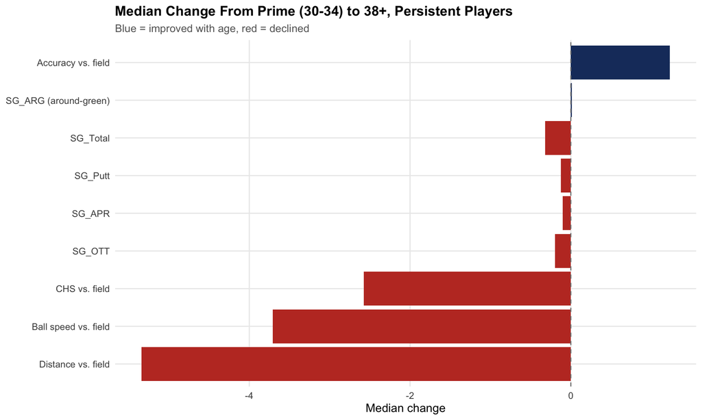

```r
metric_order <- c("dist_vs_field", "speed_vs_field", "chs_vs_field", "sg_ott",
                   "sg_apr", "sg_putt", "sg_total", "sg_arg", "acc_vs_field")
metric_labels <- c(
  dist_vs_field = "Distance vs. field", speed_vs_field = "Ball speed vs. field",
  chs_vs_field = "CHS vs. field", sg_ott = "SG_OTT", sg_apr = "SG_APR",
  sg_arg = "SG_ARG (around-green)", sg_putt = "SG_Putt", sg_total = "SG_Total",
  acc_vs_field = "Accuracy vs. field"
)

p_adaptation <- adaptation_summary %>%
  mutate(metric = factor(metric, levels = metric_order)) %>%
  ggplot(aes(median_change, metric, fill = median_change > 0)) +
  geom_col() +
  geom_vline(xintercept = 0, linetype = "dashed", color = "grey50") +
  scale_y_discrete(labels = metric_labels) +
  scale_fill_manual(values = c("TRUE" = COL_PRIMARY, "FALSE" = COL_ACCENT), guide = "none") +
  labs(
    title    = "Median Change From Prime (30-34) to 38+, Persistent Players",
    subtitle = "Blue = improved with age, red = declined",
    x = "Median change", y = NULL
  ) +
  THEME_BASE

p_adaptation
```

**Finding:** exactly the pattern hypothesized — power metrics decline (distance, ball speed, CHS all clearly negative), but **accuracy improves** (the only physical metric that goes up), and **SG_ARG (around-the-green) is essentially flat**, the least-declining of the scoring components. SG_Total still declines on net — the accuracy/short-game compensation helps, but doesn’t fully offset the power loss.

# 11. Maintained vs. Declined Comparison

Splitting persistent players by whether they kept `sg_total` positive (field-average or better) at 38+, or fell negative — does *how* they adapted differ, not just whether they were good?

```r
late_sg <- df_main %>%
  filter(player_name %in% persistent, age >= 38) %>%
  group_by(player_name) %>%
  summarise(late_sg_total = mean(sg_total), .groups = "drop") %>%
  mutate(group = if_else(late_sg_total >= 0, "Maintained (SG+)", "Declined (SG-)"))

cat("Maintained (SG+):", sum(late_sg$group == "Maintained (SG+)"),
    " Declined (SG-):", sum(late_sg$group == "Declined (SG-)"), "\n")
```

```
## Maintained (SG+): 131  Declined (SG-): 180
```

```r
dist_change <- compute_change("dist_vs_field") %>% select(player_name, dist_change = change)
acc_change <- compute_change("acc_vs_field") %>% select(player_name, acc_change = change)

group_comparison <- dist_change %>%
  inner_join(acc_change, by = "player_name") %>%
  inner_join(late_sg %>% select(player_name, group), by = "player_name") %>%
  pivot_longer(c(dist_change, acc_change), names_to = "metric", values_to = "change")

comparison_summary <- group_comparison %>%
  group_by(group, metric) %>%
  summarise(median_change = median(change), .groups = "drop")

comparison_summary %>% print()
```

```
## # A tibble: 4 x 3
##   group            metric      median_change
##   <chr>            <chr>               <dbl>
## 1 Declined (SG-)   acc_change          0.845
## 2 Declined (SG-)   dist_change        -6.76
## 3 Maintained (SG+) acc_change          1.51
## 4 Maintained (SG+) dist_change        -4.66
```

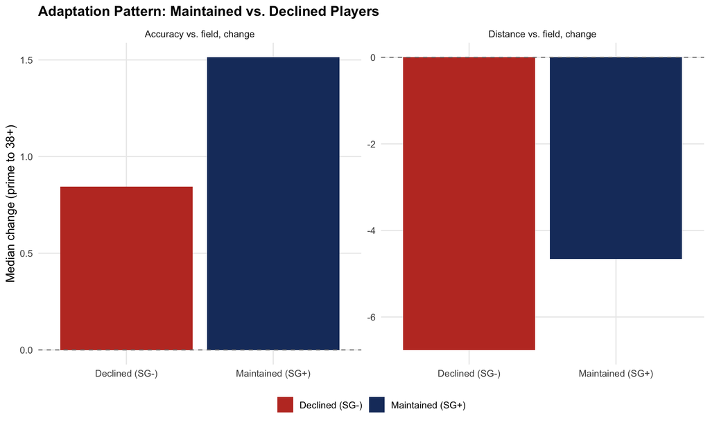

```r
p_maintained <- ggplot(comparison_summary, aes(group, median_change, fill = group)) +
  geom_col() +
  geom_hline(yintercept = 0, linetype = "dashed", color = "grey50") +
  facet_wrap(~metric, scales = "free_y", labeller = as_labeller(c(
    dist_change = "Distance vs. field, change", acc_change = "Accuracy vs. field, change"
  ))) +
  scale_fill_manual(values = c("Maintained (SG+)" = COL_PRIMARY, "Declined (SG-)" = COL_ACCENT)) +
  labs(title = "Adaptation Pattern: Maintained vs. Declined Players", x = NULL, y = "Median change (prime to 38+)", fill = NULL) +
  THEME_BASE

p_maintained
```

**Finding:** players who maintain SG_Total-positive performance at 38+ lose less distance **and** gain more accuracy than those who decline — both directions of the adaptation matter, it isn’t just “the ones who keep their distance stay good” or purely “the ones who get more accurate stay good.” Successful long-term survival combines slower power decline with a bigger accuracy gain.

# 12. Persistence Archetypes (Clustering)

Do persistent players cluster into distinct “types” of adaptation, the way Project 5 found distinct player archetypes overall?

```r
change_wide <- adaptation_all %>%
  filter(metric %in% c("dist_vs_field", "acc_vs_field", "sg_ott", "sg_apr", "sg_arg", "sg_putt")) %>%
  select(player_name, metric, change) %>%
  pivot_wider(names_from = metric, values_from = change) %>%
  filter(if_all(-player_name, ~!is.na(.x)))

cat("Players with a full change vector:", nrow(change_wide), "\n")
```

```
## Players with a full change vector: 142
```

```r
X <- change_wide %>% select(-player_name) %>% as.matrix() %>% scale()

sil_scores <- map_dbl(2:5, function(k) {
  km <- kmeans(X, centers = k, nstart = 25)
  mean(silhouette(km$cluster, dist(X))[, 3])
})
cat("Silhouette scores k=2..5:\n"); print(setNames(round(sil_scores, 3), 2:5))
```

```
## Silhouette scores k=2..5:
```

```
##     2     3     4     5
## 0.204 0.154 0.161 0.169
```

Silhouette technically favors k=2, but as in Project 5, we use **k=3** — a small step down in silhouette width for meaningfully more interpretable, distinct archetypes.

```r
set.seed(2025)
km3 <- kmeans(X, centers = 3, nstart = 25)
change_wide$cluster <- factor(km3$cluster)

centers_unscaled <- sweep(sweep(km3$centers, 2, attr(X, "scaled:scale"), `*`), 2, attr(X, "scaled:center"), `+`) %>%
  as_tibble() %>%
  mutate(cluster = row_number(), size = km3$size) %>%
  mutate(label = case_when(
    dist_vs_field < -8 & acc_vs_field > 3 ~ "Traded power for precision",
    dist_vs_field < 0 & acc_vs_field < 0  ~ "Across-the-board decliner",
    TRUE                                   ~ "Mild all-around decliner"
  ))

centers_unscaled %>% print()
```

```
## # A tibble: 3 x 9
##   dist_vs_field acc_vs_field  sg_ott  sg_apr  sg_arg sg_putt cluster  size label
##           <dbl>        <dbl>   <dbl>   <dbl>   <dbl>   <dbl>   <int> <int> <chr>
## 1         -4.23        -3.07 -0.418  -0.276  -0.0164  0.0103       1    48 Acro~
## 2         -2.93         2.14  0.0153 -0.106   0.0259 -0.189        2    47 Mild~
## 3        -10.1          4.61 -0.216   0.0573  0.0755 -0.118        3    47 Trad~
```

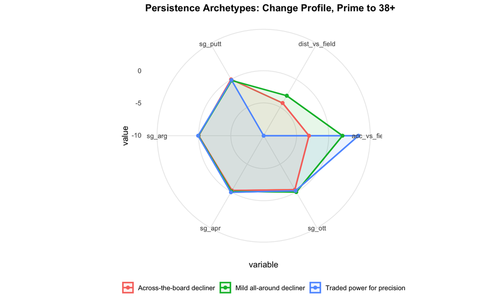

```r
radar_data <- centers_unscaled %>%
  select(label, dist_vs_field, acc_vs_field, sg_ott, sg_apr, sg_arg, sg_putt) %>%
  pivot_longer(-label, names_to = "variable", values_to = "value") %>%
  mutate(variable = factor(variable, levels = c("dist_vs_field", "acc_vs_field", "sg_ott", "sg_apr", "sg_arg", "sg_putt")))

radar_closed <- radar_data %>%
  group_by(label) %>%
  group_modify(~bind_rows(.x, .x[1, ])) %>%
  ungroup()

p_radar <- ggplot(radar_closed, aes(variable, value, group = label, color = label)) +
  geom_polygon(aes(fill = label), alpha = 0.1, linewidth = 1) +
  geom_line(linewidth = 1) +
  geom_point(size = 2) +
  coord_radar() +
  labs(title = "Persistence Archetypes: Change Profile, Prime to 38+", color = NULL, fill = NULL) +
  THEME_BASE

p_radar
```

**Finding:** three distinct archetypes emerge among persistent players — Across-the-board decliner (n= 48 ); Mild all-around decliner (n= 47 ); Traded power for precision (n= 47 ). The “traded power for precision” group shows the clearest compensation pattern (biggest distance loss, biggest accuracy gain); the “across-the-board decliner” group shows no such compensation — everything declines together.

# 13. Late-Career Survivor Profile (38+ Ever vs. Never)

The original docs’ ask, using career-average stats (not last-observed-row snapshots, which would confound still-active younger players with genuinely retired older ones).

```r
player_career_profile <- df_survival %>%
  group_by(player_name) %>%
  summarise(career_dist_vs_field = mean(dist_vs_field), career_sg_total = mean(sg_total), .groups = "drop") %>%
  left_join(df_main %>% group_by(player_name) %>% summarise(max_age = max(age), .groups = "drop"), by = "player_name") %>%
  mutate(reached_38 = max_age >= 38)

cmp <- player_career_profile %>%
  group_by(reached_38) %>%
  summarise(n = n(), mean_career_dist = mean(career_dist_vs_field), mean_career_sg = mean(career_sg_total), .groups = "drop")

cmp %>% print()
```

```
## # A tibble: 3 x 4
##   reached_38     n mean_career_dist mean_career_sg
##   <lgl>      <int>            <dbl>          <dbl>
## 1 FALSE        481             1.45        -0.218
## 2 TRUE         311            -2.52         0.0122
## 3 NA             1            -3.27        -0.244
```

```r
t_dist <- t.test(career_dist_vs_field ~ reached_38, data = player_career_profile)
t_sg <- t.test(career_sg_total ~ reached_38, data = player_career_profile)
cat("\ndistance t-test p =", format.pval(t_dist$p.value, digits = 3), "\n")
```

```
##
## distance t-test p = 2.3e-12
```

```r
cat("sg_total t-test p =", format.pval(t_sg$p.value, digits = 3), "\n")
```

```
## sg_total t-test p = 8.42e-08
```

**Finding:** players who ever reach 38+ have a **lower** career-average distance-vs-field than those who never do (p<0.001) but a **higher** career-average SG_Total (p<0.001). This ties Part A and Part B together: what predicts who survives on tour long-term isn’t raw power — it’s overall scoring ability. The whole project keeps circling back to this same nuance from a different angle each time.

# 14. Summary